# All21 Reference18 UMI≥50: disease-blind K=3 spatial niche analysis

Rendered 2026-10-11T19:55:38; report ID 261011195538

**Approved scope.** One common disease-blind K=3 niche atlas across 21 patients, followed by patient-level HC, IPF and SSc-ILD comparisons. K=4 was an accidental exploratory run and is excluded from this report.

## 1. Goal and analysis design

Construct local spatial neighborhoods from frozen Reference18 RCTD weights, describe each niche by its cell-type mixture, and test disease-associated changes in niche abundance and niche–niche adjacency without treating bins as independent biological replicates.

| parameter | value |
| --- | --- |
| input | D:\Lung ST\codex agent\stereo_seq\stereo_seq\results\reanalysis\REFERENCE18_UMI50_VOLTRON_PER_CHIP_NICHE_20261005_153036 |
| reference | six-dataset Reference18 |
| umi_min | 50 |
| patients | 21 |
| radius_um | 50.0 |
| center_bin | excluded |
| radius_implementation | exact Euclidean radius within patient/ROI; no RANN k-cap; no cross-patient edges |
| transform | zero-safe CLR followed by disease-blind equal-patient chip mean centering |
| fit_balance | 495 evaluable Bin50 per patient per repeat (minimum available, capped at 500) |
| k_candidates | 3;4;5 |
| repeats | 20 |
| selection_rule | predeclared stability, held-chip transfer, size, patient/chip coverage, single-patient dominance, spatial agreement, parsimony |
| disease_used_for_discovery | FALSE |
| primary_disease_model | patient corrected-logit niche fraction ~ chip + disease; HC3 |
| permutations | 10000 disease-label permutations within chip |
| seed | 20261011 |

## 2. K audit and interpretation boundary

K=3 was retained as the most parsimonious and most repeat-stable candidate. Chip-centering reduced chip association, but held-chip transfer remained below the predeclared validation threshold. K=3 is therefore an exploratory common resolution, not a fully validated universal atlas.

| k | repeat_ari_median | cross_chip_ari_median | silhouette_mean | spatial_edge_agreement | min_patient_coverage_n | chip_cramer_v | selected | selection_status |
| --- | --- | --- | --- | --- | --- | --- | --- | --- |
| 3 | 0.877 | 0.254 | 0.096 | 0.671 | 20 | 0.255 | True | descriptive_fallback_no_K_passed_all_predeclared_criteria |
| 4 | 0.705 | 0.246 | 0.093 | 0.615 | 20 | 0.284 | False | descriptive_fallback_no_K_passed_all_predeclared_criteria |
| 5 | 0.659 | 0.305 | 0.083 | 0.573 | 19 | 0.312 | False | descriptive_fallback_no_K_passed_all_predeclared_criteria |

## 3. Niche × cell-type composition

The upper heatmap reports uncorrected mean RCTD fractions, preserving biological composition. The lower heatmap reports cell-type-wise z scores across niches to emphasize relative enrichment used for annotation.

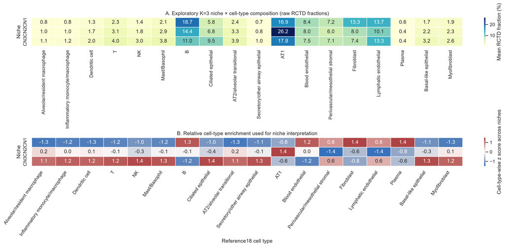

Figure 1. K=3 niche × Reference18 cell-type composition.

| niche | top3_states | largest_mean_rctd_fraction |
| --- | --- | --- |
| CN1 | B;AT1;Lymphatic endothelial | 0.187 |
| CN2 | AT1;B;Lymphatic endothelial | 0.262 |
| CN3 | AT1;Lymphatic endothelial;B | 0.178 |

## 4. Spatial localization across patients

Assignments are displayed separately for all 21 patients. Visual recurrence and spatial coherence are necessary descriptive checks, while patient-level statistics below provide inference.

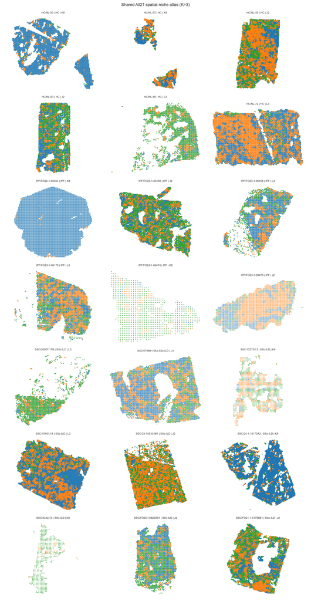

Figure 2. Spatial distribution of CN1–CN3 in all 21 patients.

## 5. Disease comparison of niche abundance

Each point represents one patient. Disease effects were estimated from corrected-logit niche fractions with chip as a covariate and evaluated using 10,000 within-chip disease-label permutations.

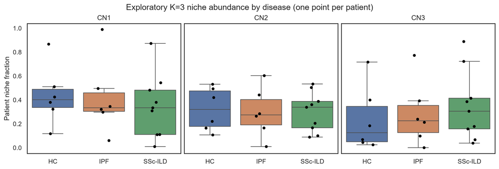

Figure 3. Patient-level niche fractions by disease.

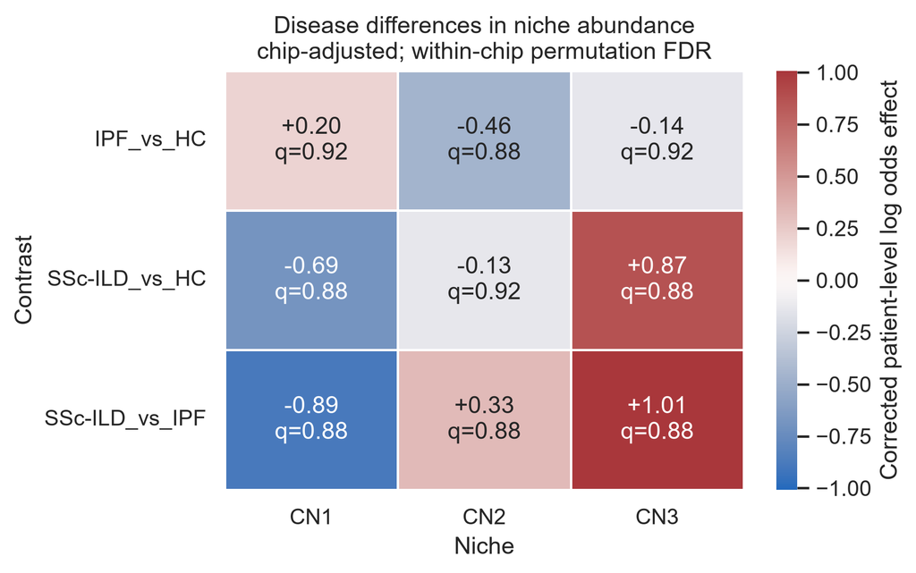

Figure 4. Chip-adjusted disease effects and permutation FDR.

| niche | contrast | log_odds_effect | odds_ratio | permutation_p | permutation_fdr_global | supported_finding |
| --- | --- | --- | --- | --- | --- | --- |
| CN1 | IPF_vs_HC | 0.201 | 1.223 | 0.858 | 0.915 | False |
| CN2 | IPF_vs_HC | -0.462 | 0.630 | 0.465 | 0.877 | False |
| CN3 | IPF_vs_HC | -0.137 | 0.872 | 0.915 | 0.915 | False |
| CN1 | SSc-ILD_vs_HC | -0.685 | 0.504 | 0.530 | 0.877 | False |
| CN2 | SSc-ILD_vs_HC | -0.133 | 0.875 | 0.834 | 0.915 | False |
| CN3 | SSc-ILD_vs_HC | 0.871 | 2.388 | 0.464 | 0.877 | False |
| CN1 | SSc-ILD_vs_IPF | -0.886 | 0.412 | 0.404 | 0.877 | False |
| CN2 | SSc-ILD_vs_IPF | 0.330 | 1.390 | 0.585 | 0.877 | False |
| CN3 | SSc-ILD_vs_IPF | 1.008 | 2.739 | 0.383 | 0.877 | False |

## 6. Disease comparison of niche–niche adjacency

Within each patient, adjacency enrichment is log2(observed/expected) for bins separated by ≤36 µm. Expected counts preserve patient-specific niche abundance. Disease inference again uses patients as replicates, chip adjustment and within-chip permutations.

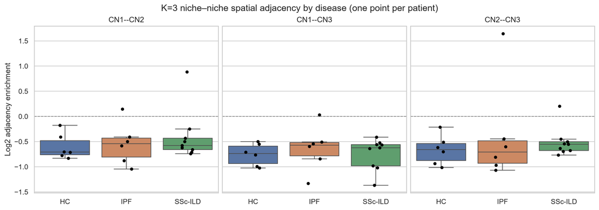

Figure 5. Patient-level niche–niche adjacency enrichment.

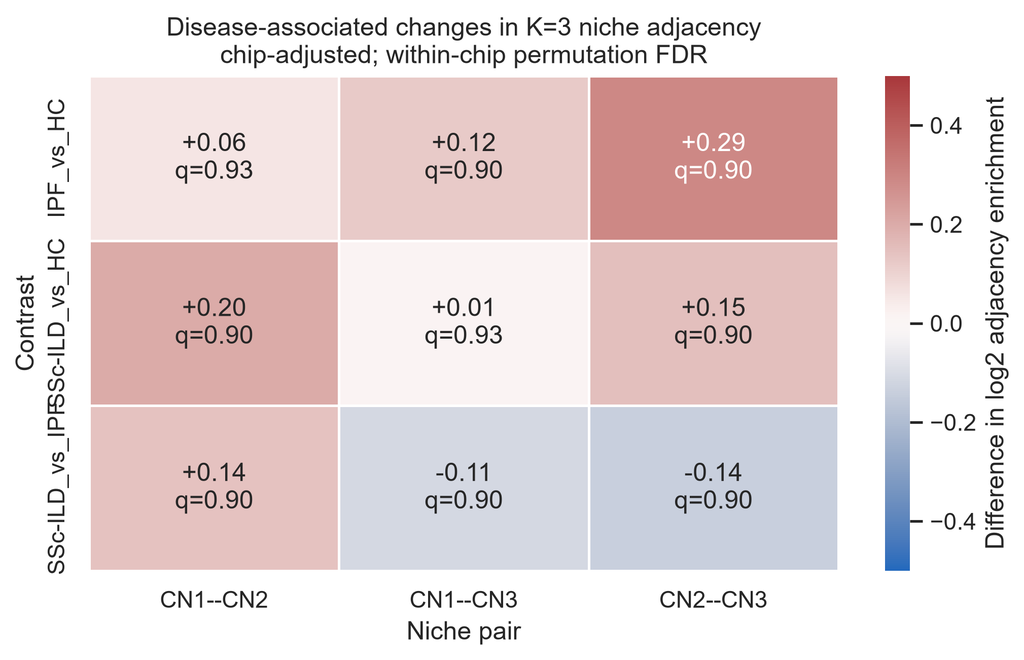

Figure 6. Differential niche–niche adjacency by disease.

| niche_pair | contrast | difference_in_log2_adjacency_enrichment | within_chip_permutation_p | permutation_fdr | supported_finding |
| --- | --- | --- | --- | --- | --- |
| CN1--CN2 | IPF_vs_HC | 0.057 | 0.831 | 0.927 | False |
| CN1--CN2 | SSc-ILD_vs_HC | 0.201 | 0.390 | 0.901 | False |
| CN1--CN2 | SSc-ILD_vs_IPF | 0.144 | 0.560 | 0.901 | False |
| CN1--CN3 | IPF_vs_HC | 0.125 | 0.455 | 0.901 | False |
| CN1--CN3 | SSc-ILD_vs_HC | 0.013 | 0.927 | 0.927 | False |
| CN1--CN3 | SSc-ILD_vs_IPF | -0.111 | 0.464 | 0.901 | False |
| CN2--CN3 | IPF_vs_HC | 0.290 | 0.382 | 0.901 | False |
| CN2--CN3 | SSc-ILD_vs_HC | 0.152 | 0.660 | 0.901 | False |
| CN2--CN3 | SSc-ILD_vs_IPF | -0.139 | 0.701 | 0.901 | False |

## 7. Conclusions

- The K=3 heatmap provides an interpretable descriptive summary of three mixed tissue-composition niches.
- No niche-abundance contrast passed permutation FDR <0.05.
- No inter-niche adjacency contrast passed permutation FDR <0.05.
- These null results do not establish biological equivalence; the atlas is exploratory and between-patient heterogeneity is substantial.
- The next justified layer is patient × niche pseudobulk analysis of raw gene counts and predeclared fibrosis, epithelial injury, vascular-remodeling and immune gene programs.

## 8. Validation and provenance

| section | check | pass | observed |
| --- | --- | --- | --- |
| atlas | input_rows_126449 | True | 126449 |
| atlas | unique_entities | True | 126449 |
| atlas | patients_21 | True | 21 |
| atlas | balanced_chip_disease | True | {"HC":{"J2":2,"K8":2,"L3":2},"IPF":{"J2":2,"K8":2,"L3":2},"SSc-ILD":{"J2":3,"K8":3,"L3":3}} |
| atlas | states_18 | True | 18 |
| atlas | weights_sum_one | True | 0.999999999999997 |
| atlas | no_cross_patient_edges | True | 467463 |
| atlas | nonempty_neighborhoods | True | 126199 |
| atlas | all_k_completed | True | [3, 4, 5] |
| atlas | selected_one_k | True | 3 |
| atlas | disease_blind_selection | True | disease not passed to clustering or K metrics |
| atlas | all_evaluable_assigned | True | 126199 |
| atlas | patient_fractions_sum_one | True | 1.0 |
| atlas | finite_disease_results | True | 9 |
| adjacency | patients_21 | True | 21 |
| adjacency | three_inter_niche_pairs | True | 3 |
| adjacency | patient_pair_rows_63 | True | 63 |
| adjacency | disease_tests_9 | True | 9 |
| adjacency | finite_enrichment | True | 63 |
| adjacency | finite_effects | True | 9 |

### Input fingerprints

| artifact | path | sha256 |
| --- | --- | --- |
| method | D:\Lung ST\codex agent\stereo_seq\stereo_seq\results\reanalysis\ALL21_SHARED_UNBIASED_DISCRETE_NICHE_ATLAS_20261011_191652_attempt4\00_METHOD_AND_INPUT_LOCK.tsv | cb9bfad6b0890f69ccfd6a7d37e597018cd5c92d2fc5263b766472a10c5ec8a7 |
| k_audit | D:\Lung ST\codex agent\stereo_seq\stereo_seq\results\reanalysis\ALL21_SHARED_UNBIASED_DISCRETE_NICHE_ATLAS_20261011_191652_attempt4\03_K_SELECTION_AUDIT.tsv | fb2a8ed7c326cf9b164675435c70081dab098bd2f4fdcdef690f1238f3cf4e87 |
| composition | D:\Lung ST\codex agent\stereo_seq\stereo_seq\results\reanalysis\ALL21_SHARED_UNBIASED_DISCRETE_NICHE_ATLAS_20261011_191652_attempt4\05_SELECTED_K_NICHE_COMPOSITION.tsv | 683d531563eaf47acc7345665420bc4322e98efe4fba57e8e30d2536dad49d2a |
| patient_abundance | D:\Lung ST\codex agent\stereo_seq\stereo_seq\results\reanalysis\ALL21_SHARED_UNBIASED_DISCRETE_NICHE_ATLAS_20261011_191652_attempt4\06_PATIENT_NICHE_ABUNDANCE.tsv | 0d3dfc73fd7c22707378841615896310de3bf935865b3637463ccb520dd84930 |
| disease_tests | D:\Lung ST\codex agent\stereo_seq\stereo_seq\results\reanalysis\ALL21_SHARED_UNBIASED_DISCRETE_NICHE_ATLAS_20261011_191652_attempt4\09_NICHE_DISEASE_TESTS.tsv | 25c15259bdb60ab87ce1c8e3b5393a13029e804247a1609f38758a6e95a08a81 |
| atlas_validation | D:\Lung ST\codex agent\stereo_seq\stereo_seq\results\reanalysis\ALL21_SHARED_UNBIASED_DISCRETE_NICHE_ATLAS_20261011_191652_attempt4\15_FINAL_VALIDATION.tsv | 99891a0a5228927447e67ae38dc2b5dfb69d9fb49af3bd89ad9b587549418ee6 |
| celltype_heatmap | D:\Lung ST\codex agent\stereo_seq\stereo_seq\results\reanalysis\ALL21_K3_NICHE_HEATMAP_DISEASE_COMPARISON_20261011_192920_attempt2\figures\FIG01_K3_NICHE_X_CELLTYPE_HEATMAP.png | a57dbfb0a36aba2f836f22514a5b8abb126edf1783e601b9ddd83b4c51a852ed |
| disease_distribution | D:\Lung ST\codex agent\stereo_seq\stereo_seq\results\reanalysis\ALL21_K3_NICHE_HEATMAP_DISEASE_COMPARISON_20261011_192920_attempt2\figures\FIG02_PATIENT_NICHE_FRACTION_BY_DISEASE.png | 1040b18780cf4826d5bc66b52e94c0622550911e796fb5eff37385534d8cc229 |
| disease_effect | D:\Lung ST\codex agent\stereo_seq\stereo_seq\results\reanalysis\ALL21_K3_NICHE_HEATMAP_DISEASE_COMPARISON_20261011_192920_attempt2\figures\FIG03_DISEASE_EFFECT_HEATMAP.png | 0514dc4a47abf5e5f0fb1d8903c028f280a7486b892135c0f28bf26a1591bb3c |
| spatial_atlas | D:\Lung ST\codex agent\stereo_seq\stereo_seq\results\reanalysis\ALL21_SHARED_UNBIASED_DISCRETE_NICHE_ATLAS_20261011_191652_attempt4\figures\FIG03_ALL21_SPATIAL_NICHE_ATLAS.png | 471cb3fce7410c85719547eba3d9f1865fc307d488a6e1a60567f2dcf438f99d |
| adjacency_table | D:\Lung ST\codex agent\stereo_seq\stereo_seq\results\reanalysis\ALL21_K3_DIFFERENTIAL_NICHE_ADJACENCY_20261011_195242\03_DIFFERENTIAL_NICHE_ADJACENCY.tsv | ced977fd88d94e947bcbc9a2c497ce7bd41f8ca77869090aa1b2048673f95784 |
| adjacency_distribution | D:\Lung ST\codex agent\stereo_seq\stereo_seq\results\reanalysis\ALL21_K3_DIFFERENTIAL_NICHE_ADJACENCY_20261011_195242\figures\FIG01_PATIENT_K3_NICHE_ADJACENCY_BY_DISEASE.png | 9108a8eca21f3ad48a730f77a259e7ca624ac9af786777b0daf7cc478fe3952e |
| adjacency_effect | D:\Lung ST\codex agent\stereo_seq\stereo_seq\results\reanalysis\ALL21_K3_DIFFERENTIAL_NICHE_ADJACENCY_20261011_195242\figures\FIG02_DIFFERENTIAL_K3_NICHE_ADJACENCY_HEATMAP.png | f732779bd9e5d6d40584ace0c591f4f7d06c02ad590179a578f0e543417eebc1 |
| adjacency_validation | D:\Lung ST\codex agent\stereo_seq\stereo_seq\results\reanalysis\ALL21_K3_DIFFERENTIAL_NICHE_ADJACENCY_20261011_195242\04_FINAL_VALIDATION.tsv | 231220a289dabdb79fc51533bdcabbf9a8eff7af8f197b6b78a1badc76a12af4 |

Python 3.12.14 (main, Aug 25 2026, 14:01:42) [MSC v.1944 64 bit (AMD64)]  
Windows-11-10.0.26200-SP0  
numpy 2.4.6; pandas 3.0.5